# Initial experiments

2025-03-28

Let’s get started with our initial draft. Let’s go with the Samusik bone marrow dataset. We hypothesize that different datasets will have different solution spaces. We think the PBMC 3k dataset for example will have many more solutions because it’s really just three blobs.

```r
library(HDCytoData)
library(tidyverse)
```

Let’s upload the data.

```r
se <- HDCytoData::Samusik_01_SE()
```

```
## see ?HDCytoData and browseVignettes('HDCytoData') for documentation
```

```
## loading from cache
```

```r
se
```

```
## class: SummarizedExperiment
## dim: 86864 51
## metadata(0):
## assays(1): exprs
## rownames: NULL
## rowData names(2): sample_id population_id
## colnames(51): Time Cell_length ... Cisplatin beadDist
## colData names(3): channel_name marker_name marker_class
```

Ok, now we subsample.

```r
num_cells <- 1000
se <- se[sample(nrow(se), num_cells),]
se
```

```
## class: SummarizedExperiment
## dim: 1000 51
## metadata(0):
## assays(1): exprs
## rownames: NULL
## rowData names(2): sample_id population_id
## colnames(51): Time Cell_length ... Cisplatin beadDist
## colData names(3): channel_name marker_name marker_class
```

And now we pull out the expression matrix.

```r
cells <- se@assays@data$exprs %>% as_tibble()
cells
```

```
## # A tibble: 1,000 × 51
##        Time Cell_length   BC1   BC2   BC3    BC4   BC5      BC6  Ter119 CD45.2
##       <dbl>       <dbl> <dbl> <dbl> <dbl>  <dbl> <dbl>    <dbl>   <dbl>  <dbl>
##  1  3651557          25 123.  126.  180.  26.5   2.31  12.5     -0.417    3.04
##  2  1395393          19 134.   82.4 140.   8.92  3.94   4.76    -0.214    7.47
##  3 15604238          23 434.  293.  395.  20.4   2.24   2.24    -0.0975  14.2
##  4  7956198          31  65.8  73.5  90.7  8.30  3.62   2.16     0.0597   9.56
##  5  6517289          25 131.  113.  100.  13.8   9.86   3.96    -0.277    4.44
##  6  3310608          14  70.6  85.4  64.3  0.326 4.87   1.26     1.31     8.58
##  7  3240080          20 337.  213.  352.  15.8   7.39  21.9     -0.372   42.5
##  8  9444571          24 408.  407.  341.  11.4   2.92   2.17    -0.755    5.08
##  9 12590699          22 195.  169.  200.  18.8   9.95  -0.00664 -0.464   17.8
## 10 15693202          18 400.  216.  292.   4.88  0.332  1.95    -0.519   12.6
## # ℹ 990 more rows
## # ℹ 41 more variables: Ly6G <dbl>, IgD <dbl>, CD11c <dbl>, F480 <dbl>,
## #   CD3 <dbl>, NKp46 <dbl>, CD23 <dbl>, CD34 <dbl>, CD115 <dbl>, CD19 <dbl>,
## #   `120g8` <dbl>, CD8 <dbl>, Ly6C <dbl>, CD4 <dbl>, CD11b <dbl>, CD27 <dbl>,
## #   CD16_32 <dbl>, SiglecF <dbl>, Foxp3 <dbl>, B220 <dbl>, CD5 <dbl>,
## #   FceR1a <dbl>, TCRgd <dbl>, CCR7 <dbl>, Sca1 <dbl>, CD49b <dbl>, cKit <dbl>,
## #   CD150 <dbl>, CD25 <dbl>, TCRb <dbl>, CD43 <dbl>, CD64 <dbl>, CD138 <dbl>, …
```

And now we pull out the relevant markers.

```r
surface <- colData(se) %>% as_tibble() %>% dplyr::filter(marker_class == "type") %>% .[["marker_name"]]
surface
```

```
##  [1] "Ter119"  "CD45.2"  "Ly6G"    "IgD"     "CD11c"   "F480"    "CD3"
##  [8] "NKp46"   "CD23"    "CD34"    "CD115"   "CD19"    "120g8"   "CD8"
## [15] "Ly6C"    "CD4"     "CD11b"   "CD27"    "CD16_32" "SiglecF" "Foxp3"
## [22] "B220"    "CD5"     "FceR1a"  "TCRgd"   "CCR7"    "Sca1"    "CD49b"
## [29] "cKit"    "CD150"   "CD25"    "TCRb"    "CD43"    "CD64"    "CD138"
## [36] "CD103"   "IgM"     "CD44"    "MHCII"
```

And we subset our data.

```r
cells <- cells[surface]
cells
```

```
## # A tibble: 1,000 × 39
##     Ter119 CD45.2    Ly6G      IgD   CD11c   F480      CD3  NKp46   CD23   CD34
##      <dbl>  <dbl>   <dbl>    <dbl>   <dbl>  <dbl>    <dbl>  <dbl>  <dbl>  <dbl>
##  1 -0.417    3.04 -0.187  -0.195    0.0682  7.06   0.529    0.208 -0.389  5.08
##  2 -0.214    7.47  0.226  20.7     -0.582  -0.680 -0.646   -0.585 -0.472  0.512
##  3 -0.0975  14.2   0.585  -0.704   -0.0964 11.4   -0.313    0.313 -0.886  6.10
##  4  0.0597   9.56  2.29   25.0      0.937   4.68  -0.00691  1.29   4.22   1.06
##  5 -0.277    4.44  2.86    0.603   -0.286   1.31   0.108    2.25   1.58  -0.159
##  6  1.31     8.58 -0.0654 -0.147   -0.141  -0.634 -0.143    0.560 -0.541 -0.511
##  7 -0.372   42.5  -0.768  -0.00612 -0.0859 53.2    0.437    1.01  -0.502  0.677
##  8 -0.755    5.08  1.43    1.43    -0.459  16.4   -0.576   12.3   -0.377  3.55
##  9 -0.464   17.8   3.51   -0.0466  -0.308   9.45  -0.213   -0.274 12.3    8.56
## 10 -0.519   12.6   0.328  -0.110   -0.258   3.39   0.0768  -0.775 -0.452  0.306
## # ℹ 990 more rows
## # ℹ 29 more variables: CD115 <dbl>, CD19 <dbl>, `120g8` <dbl>, CD8 <dbl>,
## #   Ly6C <dbl>, CD4 <dbl>, CD11b <dbl>, CD27 <dbl>, CD16_32 <dbl>,
## #   SiglecF <dbl>, Foxp3 <dbl>, B220 <dbl>, CD5 <dbl>, FceR1a <dbl>,
## #   TCRgd <dbl>, CCR7 <dbl>, Sca1 <dbl>, CD49b <dbl>, cKit <dbl>, CD150 <dbl>,
## #   CD25 <dbl>, TCRb <dbl>, CD43 <dbl>, CD64 <dbl>, CD138 <dbl>, CD103 <dbl>,
## #   IgM <dbl>, CD44 <dbl>, MHCII <dbl>
```

Now we do a transform.

```r
cells <- asinh(cells/5) %>% as_tibble()
cells
```

```
## # A tibble: 1,000 × 39
##     Ter119 CD45.2    Ly6G      IgD   CD11c   F480      CD3   NKp46    CD23
##      <dbl>  <dbl>   <dbl>    <dbl>   <dbl>  <dbl>    <dbl>   <dbl>   <dbl>
##  1 -0.0833  0.576 -0.0373 -0.0390   0.0136  1.14   0.106    0.0417 -0.0778
##  2 -0.0428  1.19   0.0452  2.13    -0.116  -0.136 -0.129   -0.117  -0.0942
##  3 -0.0195  1.76   0.117  -0.140   -0.0193  1.57  -0.0625   0.0627 -0.176
##  4  0.0119  1.40   0.443   2.31     0.186   0.835 -0.00138  0.255   0.766
##  5 -0.0554  0.800  0.544   0.120   -0.0571  0.259  0.0215   0.437   0.311
##  6  0.260   1.31  -0.0131 -0.0294  -0.0282 -0.126 -0.0286   0.112  -0.108
##  7 -0.0743  2.84  -0.153  -0.00122 -0.0172  3.06   0.0873   0.200  -0.100
##  8 -0.150   0.893  0.282   0.283   -0.0917  1.91  -0.115    1.63   -0.0754
##  9 -0.0927  1.98   0.655  -0.00932 -0.0615  1.39  -0.0426  -0.0547  1.64
## 10 -0.104   1.66   0.0656 -0.0220  -0.0516  0.634  0.0154  -0.154  -0.0902
## # ℹ 990 more rows
## # ℹ 30 more variables: CD34 <dbl>, CD115 <dbl>, CD19 <dbl>, `120g8` <dbl>,
## #   CD8 <dbl>, Ly6C <dbl>, CD4 <dbl>, CD11b <dbl>, CD27 <dbl>, CD16_32 <dbl>,
## #   SiglecF <dbl>, Foxp3 <dbl>, B220 <dbl>, CD5 <dbl>, FceR1a <dbl>,
## #   TCRgd <dbl>, CCR7 <dbl>, Sca1 <dbl>, CD49b <dbl>, cKit <dbl>, CD150 <dbl>,
## #   CD25 <dbl>, TCRb <dbl>, CD43 <dbl>, CD64 <dbl>, CD138 <dbl>, CD103 <dbl>,
## #   IgM <dbl>, CD44 <dbl>, MHCII <dbl>
```

And at this point, I think we are in business. Here is what we need to do. We need to run UMAP many times. We can produce a list of each run. We can then track a specific cell ID (eg. row 1). We can then plot its position across all runs. We can produce more sophisticated visuals later, but this is a place to start.

```r
library(umap)

num_runs <- 100
dimr_list <- lapply(seq(num_runs), function(i) {
    set.seed(i)
    result <- umap::umap(cells, preserve.seed = TRUE)$layout %>% as_tibble()
    names(result) <- c("umap1", "umap2")
    return(result)
})
dimr_list[1]
```

```
## [[1]]
## # A tibble: 1,000 × 2
##     umap1 umap2
##     <dbl> <dbl>
##  1 -1.31   5.85
##  2  2.59  -8.68
##  3 -3.44   2.08
##  4  3.21  -8.41
##  5 -1.44   5.41
##  6  3.66  -4.53
##  7 -0.693 -4.54
##  8 -4.63   2.79
##  9 -2.21   5.18
## 10 -3.59   2.34
## # ℹ 990 more rows
```

Great. And now we have our maps. For the purpose of a sanity check, let’s go ahead and plot one of them.

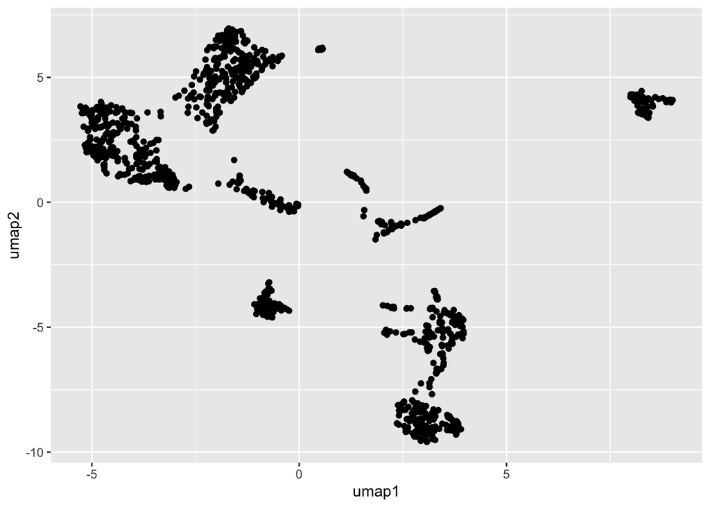

```r
ggplot(dimr_list[[1]], aes(x = umap1, y = umap2)) + geom_point()
```

Ok, that looks like what we would expect to look like. Now what we are going to do is produce a new map that simply has one cell being tracked across each run.

```r
cell_id <- 1
one_cell <- lapply(dimr_list, function(i) {
    return(i[cell_id,])
}) %>% bind_rows()

one_cell
```

```
## # A tibble: 100 × 2
##     umap1 umap2
##     <dbl> <dbl>
##  1 -1.31   5.85
##  2 -3.73   2.49
##  3 -2.23   6.68
##  4 -2.43   6.31
##  5 -3.72   2.32
##  6 -3.96   4.88
##  7 -0.297  5.60
##  8  0.302  5.63
##  9 -2.55   7.25
## 10 -0.250  5.91
## # ℹ 90 more rows
```

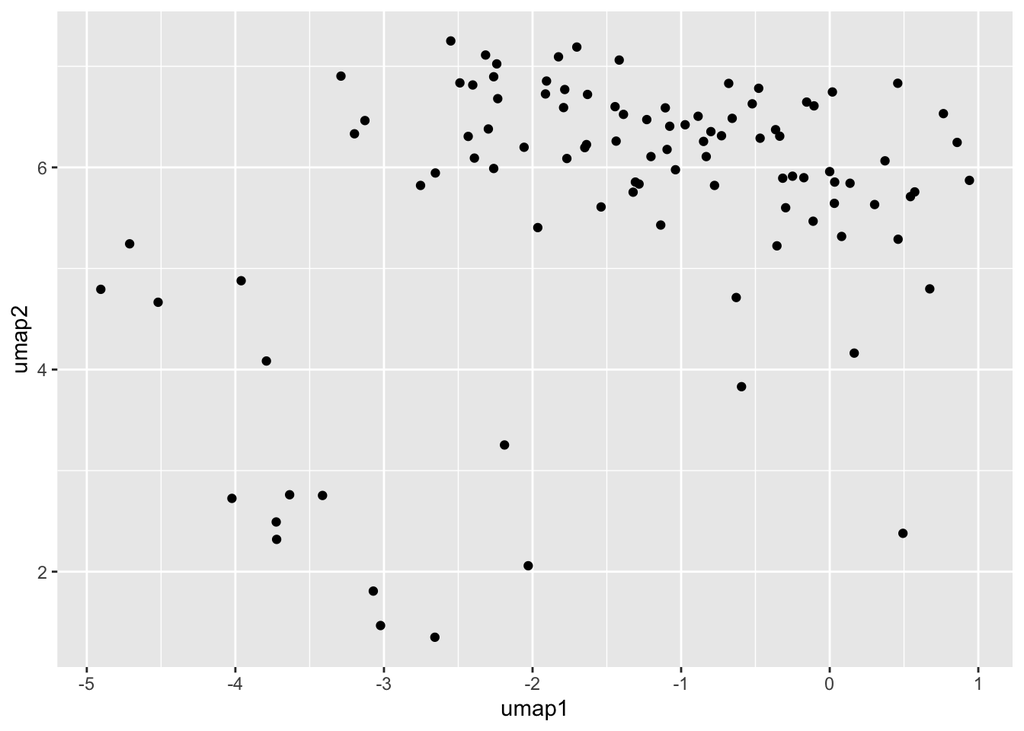

```r
ggplot(one_cell, aes(x = umap1, y = umap2)) + geom_point()
```

Bear in mind the xy coordinates. If these points are near each other, and the coordinates are not fixed, then you might see one or both axes very much zoomed in.

Now let’s output our work so we don’t have to run this again a bunch of times.

```r
setwd(here::here("output"))
readr::write_rds(dimr_list, "umap_list_1000_cells_100_runs.rds")
```